# Détection de Texte Généré par IA

Features Stylométriques · TF-IDF · SVD · AFD · Classification Bayésienne MCMC

TORRES Diego, WU Lucas — ESIEE 2025-2026 — E4 AP-4209

19/02/2026

# 1. Préambule

## 1.1 Contexte

La prolifération des grands modèles de langage (LLM) rend urgente la capacité à distinguer automatiquement les textes humains des textes générés par IA. Ces derniers présentent des patterns stylistiques caractéristiques : phrases plus longues et régulières, vocabulaire plus riche mais moins naturel, recours fréquent à des marqueurs discursifs formels.

Ce projet implémente une pipeline complète de classification supervisée :

1. **Features stylométriques** — métriques linguistiques de surface : TTR, lisibilité, variabilité des phrases, entropie…
2. **TF-IDF avec bigrammes** — vectorisation du contenu lexical
3. **SVD tronquée** — réduction vers un espace sémantique latent dense
4. **AFD (Analyse Factorielle Discriminante)** — projection maximisant la séparation entre classes
5. **Classification bayésienne MCMC** — inférence probabiliste complète via NUTS/HMC

## 1.2 Objectifs

- Distinguer textes humains (label 0) et textes IA (label 1)
- Fournir des probabilités bien calibrées (non des décisions binaires dures)
- Valider par k-fold stratifié pour garantir la robustesse

```r
# ═══════════════════════════════════════════════════════════════════
#  CHARGEMENT DES DONNÉES
# ═══════════════════════════════════════════════════════════════════
cat("====== CHARGEMENT DES DONNEES ======\n")
```

```
## ====== CHARGEMENT DES DONNEES ======
```

```r
base_kaggle    <- file.path("data", "llm-detect-ai-generated-text",
                            "llm-detect-ai-generated-text")
path_kag_train <- file.path(base_kaggle, "train_essays.csv")
path_kag_test  <- file.path(base_kaggle, "test_essays.csv")
path_kag_sub   <- file.path(base_kaggle, "sample_submission.csv")

stopifnot(file.exists(path_kag_train), file.exists(path_kag_test))

kag_train <- read_csv(path_kag_train, show_col_types = FALSE)
kag_test  <- read_csv(path_kag_test,  show_col_types = FALSE)
kag_sub   <- read_csv(path_kag_sub,   show_col_types = FALSE)

cat(sprintf("Kaggle train : %d lignes x %d col\n", nrow(kag_train), ncol(kag_train)))
```

```
## Kaggle train : 1378 lignes x 4 col
```

```r
cat(sprintf("Kaggle test  : %d lignes x %d col\n", nrow(kag_test),  ncol(kag_test)))
```

```
## Kaggle test  : 3 lignes x 3 col
```

```r
# ── DRCAT ──────────────────────────────────────────────────────────
load_drcat <- function(path) {
  if (!file.exists(path)) { warning(paste("Introuvable :", path)); return(NULL) }
  df <- read_csv(path, show_col_types = FALSE)
  if ("label" %in% names(df) && !"generated" %in% names(df))
    df <- dplyr::rename(df, generated = label)
  df
}

drcat_raw <- Filter(Negate(is.null), lapply(
  file.path("data", paste0("train_drcat_0", 1:4, ".csv")),
  load_drcat
))

ensure_cols <- function(df, cols) {
  for (col in setdiff(cols, names(df))) df[[col]] <- NA
  df
}
KEEP <- c("essay_id", "text", "source", "prompt", "fold", "generated")

drcat_all <- dplyr::bind_rows(lapply(drcat_raw, function(df)
  ensure_cols(df, KEEP) |> dplyr::select(dplyr::all_of(KEEP))
))

cat(sprintf("DRCAT total  : %d lignes\n", nrow(drcat_all)))
```

```
## DRCAT total  : 159456 lignes
```

```r
cat("Distribution DRCAT :\n")
```

```
## Distribution DRCAT :
```

```r
print(table(drcat_all$generated, useNA = "ifany"))
```

```
##
##      0      1
## 115372  44084
```

# 2. Données et Prétraitement

## 2.1 Fusion et nettoyage

```r
kag_train2 <- tibble(
  essay_id  = as.character(kag_train$id),
  text      = kag_train$text,
  source    = "kaggle",
  prompt    = if ("prompt_id" %in% names(kag_train))
                as.character(kag_train$prompt_id) else NA_character_,
  fold      = NA_real_,
  generated = as.integer(kag_train$generated)
)

train_all <- dplyr::bind_rows(kag_train2, drcat_all) |>
  dplyr::filter(!is.na(text)) |>
  dplyr::mutate(
    text      = clean_text(text),
    generated = as.integer(generated)
  ) |>
  dplyr::filter(nchar(text) > 30, generated %in% c(0L, 1L))

# BUG CORRIGÉ : utiliser safe_texts() pour le test
# garantit l'absence de NA qui causent le crash de itoken
test_df <- tibble(
  id   = kag_test$id,
  text = safe_texts(kag_test$text)
) |> dplyr::filter(nchar(text) > 5)

cat(sprintf("train_all : %d textes\n", nrow(train_all)))
```

```
## train_all : 160834 textes
```

```r
cat(sprintf("test      : %d textes\n", nrow(test_df)))
```

```
## test      : 3 textes
```

```r
cat(sprintf("Note : le fichier test_essays.csv de LLM-Detect contient\n"))
```

```
## Note : le fichier test_essays.csv de LLM-Detect contient
```

```r
cat(sprintf("  intentionnellement peu de lignes (fichier exemple Kaggle).\n"))
```

```
##   intentionnellement peu de lignes (fichier exemple Kaggle).
```

```r
cat(sprintf("  La pipeline de soumission est fonctionnelle quelle que soit la taille.\n"))
```

```
##   La pipeline de soumission est fonctionnelle quelle que soit la taille.
```

```r
cat("\nDistribution train_all :\n")
```

```
##
## Distribution train_all :
```

```r
print(table(train_all$generated))
```

```
##
##      0      1
## 116747  44087
```

```r
cat(sprintf("Proportion IA : %.1f%%\n", 100 * mean(train_all$generated == 1)))
```

```
## Proportion IA : 27.4%
```

## 2.2 Analyse exploratoire

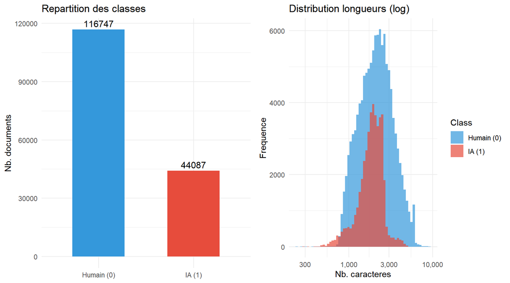

```r
eda_df <- train_all |>
  dplyr::mutate(
    n_chars = nchar(text),
    n_words = str_count(text, "\\w+"),
    Class   = factor(generated, labels = c("Humain (0)", "IA (1)"))
  )

p_cls <- ggplot(eda_df, aes(x = Class, fill = Class)) +
  geom_bar(width = 0.55) +
  geom_text(stat = "count", aes(label = after_stat(count)), vjust = -0.4, size = 4) +
  scale_fill_manual(values = c("#3498db", "#e74c3c")) +
  labs(title = "Repartition des classes", x = NULL, y = "Nb. documents") +
  theme_minimal() + theme(legend.position = "none")

p_len <- ggplot(eda_df, aes(x = n_chars, fill = Class)) +
  geom_histogram(bins = 60, alpha = 0.7, position = "identity") +
  scale_x_log10(labels = comma) +
  scale_fill_manual(values = c("#3498db", "#e74c3c")) +
  labs(title = "Distribution longueurs (log)", x = "Nb. caracteres", y = "Frequence") +
  theme_minimal()

grid.arrange(p_cls, p_len, ncol = 2)
```

```r
eda_df |>
  dplyr::group_by(Class) |>
  dplyr::summarise(
    N         = n(),
    Moy_chars = round(mean(n_chars)),
    Med_chars = round(median(n_chars)),
    Moy_mots  = round(mean(n_words)),
    P10       = round(quantile(n_chars, .10)),
    P90       = round(quantile(n_chars, .90))
  ) |>
  knitr::kable(caption = "Statistiques descriptives par classe")
```

Statistiques descriptives par classe

| Class | N | Moy_chars | Med_chars | Moy_mots | P10 | P90 |
| --- | --- | --- | --- | --- | --- | --- |
| Humain (0) | 116747 | 2328 | 2118 | 425 | 1115 | 3844 |
| IA (1) | 44087 | 1913 | 1900 | 323 | 1154 | 2561 |

# 3. Extraction de Caractéristiques

## 3.1 Features stylométriques

| Feature | Interprétation |
| --- | --- |
| `ttr` | Type-Token Ratio — richesse du vocabulaire |
| `sent_len_sd` | Variabilité des longueurs de phrases |
| `flesch` | Score de lisibilité de Flesch (approché) |
| `hapax_ratio` | Mots n’apparaissant qu’une fois |
| `discourse_markers` | Connecteurs formels typiques IA |
| `char_bigram_entropy` | Proxy de perplexité (entropie bigrammes chars) |

```r
cat("====== EXTRACTION STYLOMETRIQUE (train_all) ======\n")
```

```
## ====== EXTRACTION STYLOMETRIQUE (train_all) ======
```

```r
# BUG CORRIGÉ : le cache evite de recalculer au refit final
stylo_all <- extract_stylo(train_all$text, cache_file = "cache_stylo_all.rds")
```

```
##   Extraction stylo : 160834 textes | 21 coeurs
##   Cache sauvegarde : cache_stylo_all.rds
```

```r
cat(sprintf("  %d features extraites\n", ncol(stylo_all)))
```

```
##   17 features extraites
```

```r
knitr::kable(round(head(stylo_all, 4), 4),
             caption = "Features stylometriques — 4 premiers textes")
```

Features stylometriques — 4 premiers textes

| char_count | word_count | sent_count | avg_sent_len | sent_len_sd | avg_word_len | ttr | hapax_ratio | flesch | lex_entropy | punct_rate | comma_rate | upper_rate | discourse_markers | ai_phrases | long_word_rate | char_bigram_entropy |
| --- | --- | --- | --- | --- | --- | --- | --- | --- | --- | --- | --- | --- | --- | --- | --- | --- |
| 3286 | 584 | 24 | 24.3333 | 14.1692 | 4.6284 | 0.5086 | 0.3682 | 48.1384 | 5.1710 | 0.1130 | 0.0685 | 0.0180 | 0.0017 | 0.0000 | 0.2158 | 5.1651 |
| 2734 | 462 | 27 | 17.1111 | 6.7216 | 4.9199 | 0.5563 | 0.4069 | 44.0724 | 5.1329 | 0.1104 | 0.0519 | 0.0168 | 0.0043 | 0.0022 | 0.2489 | 5.1976 |
| 4424 | 744 | 48 | 15.5000 | 5.8528 | 4.9476 | 0.4798 | 0.3481 | 41.3469 | 5.3132 | 0.1035 | 0.0390 | 0.0140 | 0.0040 | 0.0013 | 0.2661 | 5.1921 |
| 4011 | 686 | 50 | 13.7200 | 7.2731 | 4.8484 | 0.5612 | 0.4227 | 52.6902 | 5.5020 | 0.1341 | 0.0554 | 0.0192 | 0.0058 | 0.0015 | 0.2405 | 5.2483 |

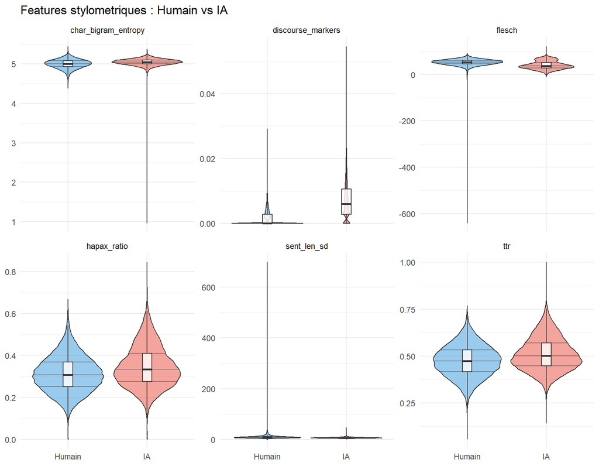

```r
stylo_plot <- stylo_all |>
  dplyr::mutate(Class = factor(train_all$generated, labels = c("Humain", "IA"))) |>
  dplyr::select(Class, ttr, sent_len_sd, flesch, hapax_ratio,
                discourse_markers, char_bigram_entropy)

stylo_long <- tidyr::pivot_longer(stylo_plot, -Class,
                                  names_to = "Feature", values_to = "Value")

ggplot(stylo_long, aes(x = Class, y = Value, fill = Class)) +
  geom_violin(alpha = 0.5, draw_quantiles = c(0.25, 0.5, 0.75)) +
  geom_boxplot(width = 0.12, outlier.shape = NA, fill = "white", alpha = 0.8) +
  facet_wrap(~Feature, scales = "free_y", ncol = 3) +
  scale_fill_manual(values = c("#3498db", "#e74c3c")) +
  labs(title = "Features stylometriques : Humain vs IA", x = NULL, y = NULL) +
  theme_minimal() + theme(legend.position = "none")
```

## 3.2 Split stratifié 80/20

```r
set.seed(42)
idx_tr   <- caret::createDataPartition(train_all$generated, p = 0.80, list = FALSE)
train    <- train_all[ idx_tr, ]
valid    <- train_all[-idx_tr, ]
stylo_tr <- stylo_all[ idx_tr, ]
stylo_va <- stylo_all[-idx_tr, ]

cat(sprintf("Train  : %d  (%.1f%% IA)\n", nrow(train), 100 * mean(train$generated == 1)))
```

```
## Train  : 128668  (27.3% IA)
```

```r
cat(sprintf("Valid  : %d  (%.1f%% IA)\n", nrow(valid), 100 * mean(valid$generated == 1)))
```

```
## Valid  : 32166  (27.7% IA)
```

## 3.3 Vectorisation TF-IDF (unigrammes + bigrammes)

```r
cat("====== TF-IDF BIGRAMMES ======\n")
```

```
## ====== TF-IDF BIGRAMMES ======
```

```r
# BUG CORRIGÉ : safe_texts() appliqué avant itoken pour eviter les NA
it_tr <- itoken(safe_texts(train$text), progressbar = FALSE)
vocab <- create_vocabulary(it_tr, ngram = c(1L, 2L))
vocab <- prune_vocabulary(vocab,
           term_count_min     = 5,
           doc_proportion_max = 0.45,
           doc_proportion_min = 1e-4)
cat(sprintf("Vocabulaire (1+2-grammes) : %d termes\n", nrow(vocab)))
```

```
## Vocabulaire (1+2-grammes) : 332486 termes
```

```r
vectorizer <- vocab_vectorizer(vocab)
dtm_tr_raw <- create_dtm(itoken(safe_texts(train$text), progressbar = FALSE),
                         vectorizer)
dtm_va_raw <- create_dtm(itoken(safe_texts(valid$text), progressbar = FALSE),
                         vectorizer)

tfidf_model <- TfIdf$new()
x_tr_tfidf  <- tfidf_model$fit_transform(dtm_tr_raw)
x_va_tfidf  <- tfidf_model$transform(dtm_va_raw)

cat(sprintf("TF-IDF train : %d x %d\n", nrow(x_tr_tfidf), ncol(x_tr_tfidf)))
```

```
## TF-IDF train : 128668 x 332486
```

## 3.4 Réduction SVD tronquée (LSA)

```r
cat("====== SVD TRONQUEE ======\n")
```

```
## ====== SVD TRONQUEE ======
```

```r
K_SVD <- min(150L, ncol(x_tr_tfidf) - 1L, nrow(x_tr_tfidf) - 1L)
K_SVD <- max(20L, K_SVD)
cat(sprintf("Rang k = %d\n", K_SVD))
```

```
## Rang k = 150
```

```r
svd_fit  <- irlba(x_tr_tfidf, nv = K_SVD, nu = K_SVD)
x_tr_svd <- svd_fit$u %*% diag(svd_fit$d)
x_va_svd <- as.matrix(x_va_tfidf %*% svd_fit$v)

var_exp <- cumsum(svd_fit$d^2) / sum(svd_fit$d^2)
cat(sprintf("Variance cumulee parmi les %d composantes retenues :\n", K_SVD))
```

```
## Variance cumulee parmi les 150 composantes retenues :
```

```r
cat(sprintf("  k=20  : %.1f%% de la variance des %d composantes calculees\n",
            100 * var_exp[20], K_SVD))
```

```
##   k=20  : 54.7% de la variance des 150 composantes calculees
```

```r
cat(sprintf("  k=%d  : %.1f%% (par construction, somme sur toutes les comp.)\n",
            K_SVD, 100 * var_exp[K_SVD]))
```

```
##   k=150  : 100.0% (par construction, somme sur toutes les comp.)
```

```r
cat(sprintf("Note : ces pourcentages sont relatifs aux %d valeurs singulieres\n", K_SVD))
```

```
## Note : ces pourcentages sont relatifs aux 150 valeurs singulieres
```

```r
cat(sprintf("calculees, pas a la variance totale de la matrice TF-IDF originale.\n"))
```

```
## calculees, pas a la variance totale de la matrice TF-IDF originale.
```

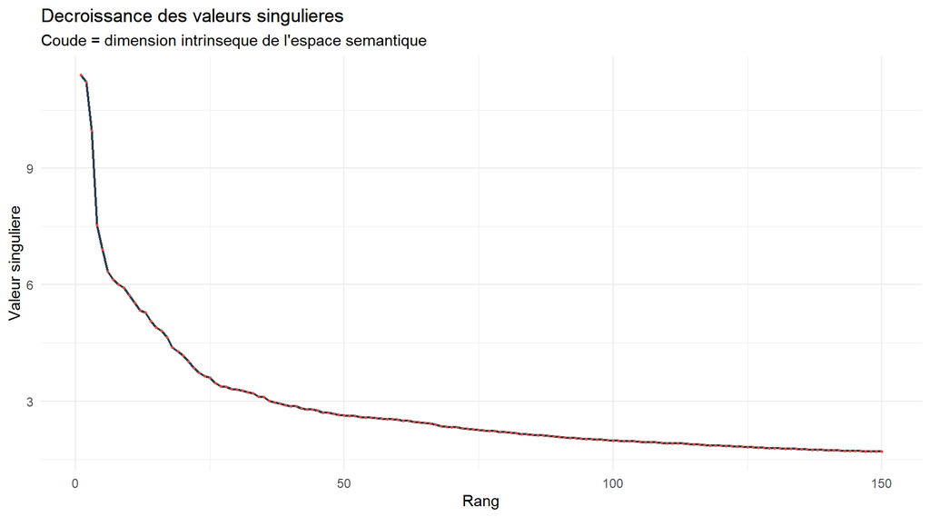

```r
data.frame(k = seq_along(svd_fit$d), sv = svd_fit$d) |>
  ggplot(aes(x = k, y = sv)) +
  geom_line(color = "#2c3e50", linewidth = 0.8) +
  geom_point(size = 0.5, color = "#e74c3c") +
  labs(title = "Decroissance des valeurs singulieres",
       subtitle = "Coude = dimension intrinseque de l'espace semantique",
       x = "Rang", y = "Valeur singuliere") +
  theme_minimal()
```

## 3.5 Fusion SVD + Stylométrie

```r
pp_stylo    <- caret::preProcess(stylo_tr, method = c("center", "scale", "nzv", "zv"))
stylo_tr_sc <- predict(pp_stylo, stylo_tr)
stylo_va_sc <- predict(pp_stylo, stylo_va)

# Aligner colonnes valid (nzv peut en retirer certaines)
for (col in setdiff(names(stylo_tr_sc), names(stylo_va_sc)))
  stylo_va_sc[[col]] <- 0
stylo_va_sc <- stylo_va_sc[, names(stylo_tr_sc), drop = FALSE]

x_tr_full <- cbind(x_tr_svd, as.matrix(stylo_tr_sc))
x_va_full <- cbind(x_va_svd, as.matrix(stylo_va_sc))
colnames(x_tr_full) <- paste0("V", seq_len(ncol(x_tr_full)))
colnames(x_va_full) <- colnames(x_tr_full)

cat(sprintf("Matrice finale (train) : %d x %d\n", nrow(x_tr_full), ncol(x_tr_full)))
```

```
## Matrice finale (train) : 128668 x 165
```

# 4. Analyse Factorielle Discriminante (AFD)

## 4.1 Fondements mathématiques

L’AFD cherche la projection $\mathbf{w}$ maximisant le **critère de Fisher** :

$$J(\mathbf{w}) = \frac{\mathbf{w}^\top
S_B \,\mathbf{w}}{\mathbf{w}^\top S_W \,\mathbf{w}}$$

- $S_B$ : matrice de dispersion **inter-classes**
- $S_W$ : matrice de dispersion **intra-classes**

La solution est le problème aux valeurs propres généralisé $S_W^{-1} S_B \,\mathbf{w} = \lambda\, \mathbf{w}$. Pour $K = 2$ classes, il existe **un unique axe LD1**.

**Justification SVD → AFD :** La TF-IDF brute est creuse et de dimension >> 10 000 colonnes, rendant l’inversion de $S_W$ instable. La SVD vers $k = 150$ dimensions denses (1) stabilise le calcul, (2) élimine le bruit, (3) approche la normalité multivariée requise.

**AFD = LDA (cas linéaire) :** Dans ce projet, l’AFD est implémentée via `MASS::lda()`, ce qui correspond à l’Analyse Discriminante Linéaire (LDA). Le sujet mentionne la possibilité d’une analyse discriminante à noyau (KDA) si la relation entre classes est non linéaire. Ici, la forte séparation linéaire observée sur LD1 (Cohen’s d > 1) justifie le choix du cas linéaire — une KDA apporterait une complexité supplémentaire sans gain attendu.

## 4.2 Application

```r
cat("====== AFD ======\n")
```

```
## ====== AFD ======
```

```r
x_tr_df <- as.data.frame(x_tr_full)
x_va_df <- as.data.frame(x_va_full)

lda_model   <- MASS::lda(x = x_tr_df, grouping = factor(train$generated))
pred_tr_lda <- predict(lda_model, newdata = x_tr_df)
pred_va_lda <- predict(lda_model, newdata = x_va_df)

pct_trace <- round(100 * lda_model$svd^2 / sum(lda_model$svd^2), 2)
cat("Proportion de trace (variance discriminante) :\n")
```

```
## Proportion de trace (variance discriminante) :
```

```r
print(pct_trace)
```

```
## [1] 100
```

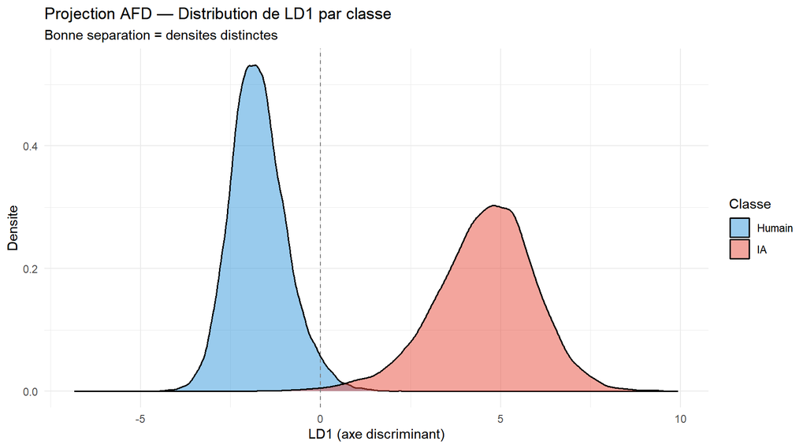

```r
scores_tr       <- as.data.frame(pred_tr_lda$x)
scores_tr$Class <- factor(train$generated, labels = c("Humain", "IA"))

ggplot(scores_tr, aes(x = LD1, fill = Class)) +
  geom_density(alpha = 0.50, adjust = 1.2, linewidth = 0.7) +
  geom_vline(xintercept = 0, linetype = "dashed", color = "grey50") +
  scale_fill_manual(values = c("#3498db", "#e74c3c")) +
  labs(title    = "Projection AFD — Distribution de LD1 par classe",
       subtitle = "Bonne separation = densites distinctes",
       x = "LD1 (axe discriminant)", y = "Densite", fill = "Classe") +
  theme_minimal()
```

```r
ld1_h    <- scores_tr$LD1[scores_tr$Class == "Humain"]
ld1_a    <- scores_tr$LD1[scores_tr$Class == "IA"]
pool_sd  <- sqrt((var(ld1_h) + var(ld1_a)) / 2)
cohens_d <- abs(mean(ld1_a) - mean(ld1_h)) / pool_sd

cat(sprintf("Moyenne LD1  Humain : %+.3f  | IA : %+.3f\n", mean(ld1_h), mean(ld1_a)))
```

```
## Moyenne LD1  Humain : -1.715  | IA : +4.560
```

```r
cat(sprintf("Ecart-type   Humain : %.3f   | IA : %.3f\n",  sd(ld1_h),   sd(ld1_a)))
```

```
## Ecart-type   Humain : 0.792   | IA : 1.410
```

```r
cat(sprintf("Cohen's d : %.3f -> effet %s\n", cohens_d,
            ifelse(cohens_d > 0.8, "Grand",
            ifelse(cohens_d > 0.5, "Moyen", "Faible"))))
```

```
## Cohen's d : 5.485 -> effet Grand
```

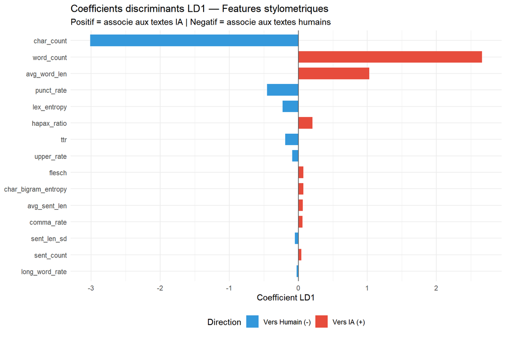

```r
# ── Visualisation des coefficients discriminants ──────────────────
# Le prof demande explicitement les "facteurs discriminants" visualisés.
# On extrait les contributions des features stylométriques sur LD1
# (les composantes SVD sont anonymes, on se concentre sur les features nommées)

# Récupérer les coefficients LD1 pour les features stylométriques
coef_all  <- as.numeric(lda_model$scaling[, 1])
feat_names <- colnames(x_tr_full)

# Isoler uniquement les features stylométriques (après les K_SVD colonnes SVD)
n_svd      <- K_SVD
n_stylo    <- ncol(stylo_tr_sc)
stylo_names <- names(stylo_tr_sc)

if (length(coef_all) >= n_svd + n_stylo) {
  coef_stylo <- coef_all[(n_svd + 1):(n_svd + n_stylo)]
  names(coef_stylo) <- stylo_names

  coef_df <- data.frame(
    Feature     = names(coef_stylo),
    Coefficient = coef_stylo
  ) |>
    dplyr::arrange(desc(abs(Coefficient))) |>
    dplyr::mutate(
      Direction = ifelse(Coefficient > 0, "Vers IA (+)", "Vers Humain (-)"),
      Feature   = factor(Feature, levels = rev(Feature))
    )

  ggplot(coef_df, aes(x = Feature, y = Coefficient, fill = Direction)) +
    geom_col(width = 0.7) +
    geom_hline(yintercept = 0, color = "grey30", linewidth = 0.5) +
    coord_flip() +
    scale_fill_manual(values = c("Vers IA (+)" = "#e74c3c",
                                  "Vers Humain (-)" = "#3498db")) +
    labs(
      title    = "Coefficients discriminants LD1 — Features stylometriques",
      subtitle = "Positif = associe aux textes IA | Negatif = associe aux textes humains",
      x        = NULL,
      y        = "Coefficient LD1",
      fill     = "Direction"
    ) +
    theme_minimal() +
    theme(legend.position = "bottom")
} else {
  cat("Visualisation des coefficients non disponible (dimensions incompatibles)\n")
}
```

```r
cat("====== SILHOUETTE ======\n")
```

```
## ====== SILHOUETTE ======
```

```r
n_sil    <- min(3000L, nrow(pred_tr_lda$x))
idx_sil  <- sample(nrow(pred_tr_lda$x), n_sil)
D_sil    <- dist(as.matrix(pred_tr_lda$x)[idx_sil, , drop = FALSE])
lab_sil  <- as.integer(train$generated[idx_sil])
sil_res  <- cluster::silhouette(lab_sil, D_sil)
sil_mean <- mean(sil_res[, "sil_width"])

cat(sprintf("Score silhouette (n=%d) : %.4f\n", n_sil, sil_mean))
```

```
## Score silhouette (n=3000) : 0.8061
```

```r
cat(sprintf("Interpretation : %s\n",
    ifelse(sil_mean > 0.5, "Bonne separation",
    ifelse(sil_mean > 0.25, "Separation raisonnable", "Separation faible"))))
```

```
## Interpretation : Bonne separation
```

[figure not shown]

```r
plot(sil_res, col = c("#3498db", "#e74c3c"),
     main = sprintf("Silhouette AFD (moy = %.3f)", sil_mean))
```

# 5. Classification Bayésienne

## 5.1 Fondements théoriques

**Théorème de Bayes :**

$$P(\boldsymbol{\theta} \mid \mathcal{D})
\propto P(\mathcal{D} \mid \boldsymbol{\theta}) \cdot
P(\boldsymbol{\theta})$$

Modèle logistique bayésien : $\text{logit}(p_i) = \alpha + \mathbf{x}_i^\top \boldsymbol{\beta}$

| Paramètre | Prior | Justification |
| --- | --- | --- |
| $\boldsymbol{\beta}$ | $\mathcal{N}(0, 2.5)$ autoscalé | Régularisation Ridge bayésienne |
| $\alpha$ | $\mathcal{N}(0, 5)$ | Prior diffus sur l’intercept |

**MCMC / NUTS :** `rstanarm` utilise le *No-U-Turn Sampler* (NUTS), variante adaptative de HMC, qui explore l’espace a posteriori bien plus efficacement que Metropolis-Hastings.

## 5.2 Entraînement

```r
cat("====== CLASSIFICATION BAYESIENNE ======\n")
```

```
## ====== CLASSIFICATION BAYESIENNE ======
```

```r
ld_tr_df     <- as.data.frame(pred_tr_lda$x)
ld_va_df     <- as.data.frame(pred_va_lda$x)
ld_tr_df$y   <- as.integer(train$generated)
ld_va_df$y   <- as.integer(valid$generated)

if (USE_RSTANARM) {
  cat("-> stan_glm : 4 chaines x 2000 iterations (NUTS/HMC)\n")
  set.seed(42)
  bayes_fit <- rstanarm::stan_glm(
    y ~ .,
    data            = ld_tr_df,
    family          = binomial("logit"),
    prior           = rstanarm::normal(0, 2.5, autoscale = TRUE),
    prior_intercept = rstanarm::normal(0, 5,   autoscale = FALSE),
    chains          = 4,
    iter            = 2000,
    warmup          = 1000,
    seed            = 42,
    refresh         = 0
  )

  cat("\n-- Diagnostics MCMC --\n")
  rhat_vals <- if (requireNamespace("bayesplot", quietly = TRUE)) {
    bayesplot::rhat(bayes_fit)
  } else {
    summary(bayes_fit$stanfit)$summary[, "Rhat"]
  }
  cat(sprintf("Rhat max : %.4f (seuil < 1.01)\n", max(rhat_vals, na.rm = TRUE)))
  if (max(rhat_vals, na.rm = TRUE) < 1.01)
    cat("Convergence satisfaisante\n")
  else
    cat("Convergence insuffisante — augmenter iter\n")

  cat("\n-- Resume modele (IC 95%) --\n")
  print(summary(bayes_fit, digits = 3, probs = c(0.025, 0.5, 0.975)))

  # posterior_epred() = API officielle rstanarm >= 2.26
  # (remplace posterior_linpred(transform=TRUE) qui est déprécié)
  p_va <- colMeans(
    rstanarm::posterior_epred(bayes_fit,
                              newdata = dplyr::select(ld_va_df, -y))
  )
} else {
  cat("-> arm::bayesglm (fallback MAP)\n")
  bayes_fit <- arm::bayesglm(y ~ ., data = ld_tr_df, family = binomial("logit"))
  p_va      <- as.numeric(predict(bayes_fit, newdata = ld_va_df, type = "response"))
}
```

```
## -> stan_glm : 4 chaines x 2000 iterations (NUTS/HMC)
##
## -- Diagnostics MCMC --
## Rhat max : 1.0006 (seuil < 1.01)
## Convergence satisfaisante
##
## -- Resume modele (IC 95%) --
##
## Model Info:
##  function:     stan_glm
##  family:       binomial [logit]
##  formula:      y ~ .
##  algorithm:    sampling
##  sample:       4000 (posterior sample size)
##  priors:       see help('prior_summary')
##  observations: 128668
##  predictors:   2
##
## Estimates:
##               mean   sd     2.5%   50%    97.5%
## (Intercept) -3.064  0.048 -3.161 -3.063 -2.975
## LD1          3.033  0.044  2.951  3.032  3.123
##
## Fit Diagnostics:
##            mean   sd    2.5%   50%   97.5%
## mean_PPD 0.273  0.000 0.273  0.273 0.274
##
## The mean_ppd is the sample average posterior predictive distribution of the outcome variable (for details see help('summary.stanreg')).
##
## MCMC diagnostics
##               mcse  Rhat  n_eff
## (Intercept)   0.001 1.000 1739
## LD1           0.001 1.001 1679
## mean_PPD      0.000 1.000 3172
## log-posterior 0.027 1.001 1424
##
## For each parameter, mcse is Monte Carlo standard error, n_eff is a crude measure of effective sample size, and Rhat is the potential scale reduction factor on split chains (at convergence Rhat=1).
```

```r
cat("Modele bayesien ajuste\n")
```

```
## Modele bayesien ajuste
```

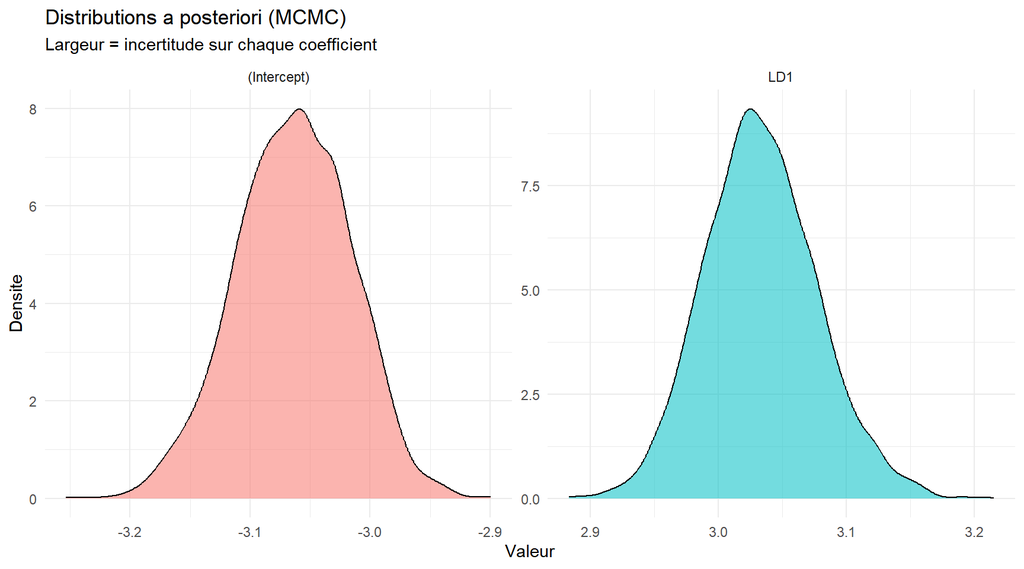

```r
bayes_draws <- as.data.frame(as.matrix(bayes_fit))
n_params    <- min(5, ncol(bayes_draws))
draws_long  <- tidyr::pivot_longer(
  bayes_draws[, seq_len(n_params), drop = FALSE],
  everything(), names_to = "Parametre", values_to = "Valeur"
)
ggplot(draws_long, aes(x = Valeur, fill = Parametre)) +
  geom_density(alpha = 0.55) +
  facet_wrap(~Parametre, scales = "free", ncol = 3) +
  labs(title    = "Distributions a posteriori (MCMC)",
       subtitle = "Largeur = incertitude sur chaque coefficient",
       x = "Valeur", y = "Densite") +
  theme_minimal() + theme(legend.position = "none")
```

# 6. Évaluation du Modèle

## 6.1 Métriques sur la validation

```r
cat("====== EVALUATION ======\n")
```

```
## ====== EVALUATION ======
```

```r
pred_class <- as.integer(p_va >= 0.5)

cm <- caret::confusionMatrix(
  factor(pred_class, levels = c(0, 1)),
  factor(ld_va_df$y, levels = c(0, 1)),
  positive = "1"
)
print(cm)
```

```
## Confusion Matrix and Statistics
##
##           Reference
## Prediction     0     1
##          0 23171   135
##          1    76  8784
##
##                Accuracy : 0.9934
##                  95% CI : (0.9925, 0.9943)
##     No Information Rate : 0.7227
##     P-Value [Acc > NIR] : < 2.2e-16
##
##                   Kappa : 0.9836
##
##  Mcnemar's Test P-Value : 6.527e-05
##
##             Sensitivity : 0.9849
##             Specificity : 0.9967
##          Pos Pred Value : 0.9914
##          Neg Pred Value : 0.9942
##              Prevalence : 0.2773
##          Detection Rate : 0.2731
##    Detection Prevalence : 0.2754
##       Balanced Accuracy : 0.9908
##
##        'Positive' Class : 1
##
```

```r
auc_val   <- safe_auc(ld_va_df$y, p_va)
brier_val <- brier_score(ld_va_df$y, p_va)
cat(sprintf("\nAUC-ROC : %.4f\n", auc_val))
```

```
##
## AUC-ROC : 0.9993
```

```r
cat(sprintf("Brier   : %.4f  (0=parfait, 0.25=aleatoire)\n", brier_val))
```

```
## Brier   : 0.0053  (0=parfait, 0.25=aleatoire)
```

```r
tibble(
  Metrique = c("Accuracy", "Precision", "Rappel", "Specificite",
               "F1-score", "AUC-ROC", "Brier"),
  Valeur   = round(c(
    cm$overall["Accuracy"],
    cm$byClass["Pos Pred Value"],
    cm$byClass["Sensitivity"],
    cm$byClass["Specificity"],
    cm$byClass["F1"],
    auc_val, brier_val
  ), 4)
) |> knitr::kable(caption = "Metriques d'evaluation completes")
```

Metriques d’evaluation completes

| Metrique | Valeur |
| --- | --- |
| Accuracy | 0.9934 |
| Precision | 0.9914 |
| Rappel | 0.9849 |
| Specificite | 0.9967 |
| F1-score | 0.9881 |
| AUC-ROC | 0.9993 |
| Brier | 0.0053 |

## 6.2 Courbe ROC

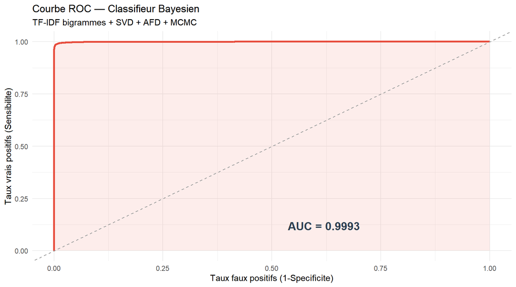

```r
roc_obj <- pROC::roc(ld_va_df$y, p_va, quiet = TRUE)
roc_df  <- data.frame(FPR = 1 - roc_obj$specificities,
                      TPR = roc_obj$sensitivities)

ggplot(roc_df, aes(x = FPR, y = TPR)) +
  geom_line(color = "#e74c3c", linewidth = 1.2) +
  geom_ribbon(aes(ymin = 0, ymax = TPR), fill = "#e74c3c", alpha = 0.10) +
  geom_abline(slope = 1, intercept = 0, linetype = "dashed", color = "grey60") +
  annotate("text", x = 0.62, y = 0.12,
           label = sprintf("AUC = %.4f", auc_val),
           size = 5, fontface = "bold", color = "#2c3e50") +
  labs(title    = "Courbe ROC — Classifieur Bayesien",
       subtitle = "TF-IDF bigrammes + SVD + AFD + MCMC",
       x = "Taux faux positifs (1-Specificite)",
       y = "Taux vrais positifs (Sensibilite)") +
  theme_minimal()
```

## 6.3 Courbe de calibration

Un modèle bien calibré place ses points sur la diagonale. Les points **au-dessus de la diagonale** indiquent une **sous-confiance** (le modèle prédit p = 0.3 mais 50% des cas sont positifs) ; en dessous, une **sur-confiance**. La régression bayésienne avec prior diffus tend à produire une bonne calibration.

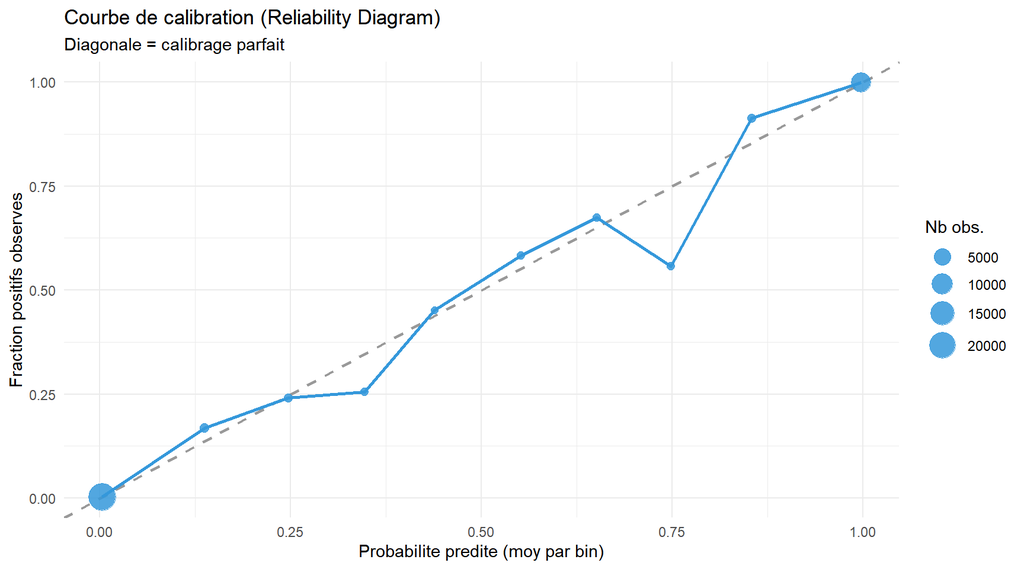

```r
calib <- data.frame(pred = p_va, obs = ld_va_df$y) |>
  dplyr::mutate(bin = cut(pred, breaks = seq(0, 1, by = 0.1),
                          include.lowest = TRUE)) |>
  dplyr::group_by(bin) |>
  dplyr::summarise(mean_pred = mean(pred), frac_pos = mean(obs),
                   n = n(), .groups = "drop") |>
  dplyr::filter(!is.na(bin))

ggplot(calib, aes(x = mean_pred, y = frac_pos)) +
  geom_abline(slope = 1, intercept = 0, linetype = "dashed",
              color = "grey60", linewidth = 0.8) +
  geom_point(aes(size = n), color = "#3498db", alpha = 0.85) +
  geom_line(color = "#3498db", linewidth = 0.9) +
  scale_size_continuous(name = "Nb obs.", range = c(2, 8)) +
  labs(title    = "Courbe de calibration (Reliability Diagram)",
       subtitle = "Diagonale = calibrage parfait",
       x = "Probabilite predite (moy par bin)",
       y = "Fraction positifs observes") +
  theme_minimal()
```